# Annotation comparison: BRC current annotation vs GENCODE v50

BRC

2026-08-21

# Purpose

We count over the BRC current annotation. The obvious question is whether we would be better off on a current public GENCODE build, or whether GENCODE would need the same cleaning we have just done. This report puts the two side by side on the same footing — same gene-body construction, same confidence and overlap code — and asks three things. How much has turned over between them? Have the gene bodies we count over moved, which on its own would change counts if we switched? And is current GENCODE any cleaner for whole-gene-body counting, or does it carry the same overlap and confidence problems? Everything is in R, against GENCODE v50.

# 1. The BRC current annotation

We read this straight from `GeneSet_Filtering.Rmd`’s output, so it already carries the biotype (from current Ensembl), the retired flag, the confidence components, the overlap and nesting flags, and the tier — no need to recompute any of it here.

```r
old <- read.csv(params$old_table, stringsAsFactors = FALSE)
old$base_id <- sub("\\..*$", "", old$gene_id)
cat(sprintf("BRC current annotation genes: %d\n", nrow(old)))
```

```
## BRC current annotation genes: 60107
```

# 2. Build the current-GENCODE gene table (native metadata)

GENCODE is easier here: its GTF already carries everything we had to fetch from biomaRt for the BRC annotation — biotype, symbol, HGNC id, `level`, transcript support level, and the multi-valued `tag` field (CCDS, basic, MANE_Select, appris) — so we build the GENCODE table offline. Gene bodies and the intrinsic signals come from `rtracklayer`. One trap: `rtracklayer` keeps only a single `tag` per feature and drops the rest, which badly undercounts things like MANE, so we parse the tags from the raw attribute column and roll them up to the gene. The import and the tag parse are both cached.

```r
gimp_cache <- file.path(params$cache_dir, sprintf("gencode_%s_import.rds", params$gencode_release))
if (file.exists(gimp_cache)) {
  gvb <- readRDS(gimp_cache)
} else {
  g <- rtracklayer::import(params$gencode_gtf)
  g <- g[as.character(seqnames(g)) %in% params$keep_seqnames]; g$type <- as.character(g$type)
  md <- data.frame(base_id = sub("\\..*$", "", g$gene_id), type = g$type,
                   transcript_id = g$transcript_id, gene_type = g$gene_type, gene_name = g$gene_name,
                   hgnc_id = g$hgnc_id, level = suppressWarnings(as.integer(g$level)),
                   seqnames = as.character(seqnames(g)), start = start(g), end = end(g),
                   strand = as.character(strand(g)), stringsAsFactors = FALSE)
  bodies <- md %>% filter(type == "gene") %>%
    transmute(base_id, chr = seqnames, start, end, strand,
              gene_biotype = gene_type, symbol = gene_name, hgnc_id, level)
  ex <- md %>% filter(!is.na(transcript_id), type %in% c("exon","start_codon","stop_codon","CDS")) %>%
    group_by(base_id, transcript_id) %>%
    summarise(n_exon = sum(type == "exon"), has_start = any(type == "start_codon"),
              has_stop = any(type == "stop_codon"), has_cds = any(type == "CDS"), .groups = "drop")
  intr <- ex %>% group_by(base_id) %>%
    summarise(n_tx = n_distinct(transcript_id), multi_exon = any(n_exon > 1),
              complete_orf = any(has_start & has_stop), is_coding = any(has_cds), .groups = "drop")
  gvb <- bodies %>% left_join(intr, by = "base_id")
  gvb <- gvb[!duplicated(gvb$base_id), ]
  saveRDS(gvb, gimp_cache)
}
```

```r
gtag_cache <- file.path(params$cache_dir, sprintf("gencode_%s_tags.rds", params$gencode_release))
if (file.exists(gtag_cache)) {
  tagr <- readRDS(gtag_cache)
} else {
  # read the GTF as a 9-column TSV; stream-decompress .gz and drop comment lines
  read_cmd <- if (grepl("\\.gz$", params$gencode_gtf))
    sprintf("gzip -dc %s | grep -v '^#'", shQuote(params$gencode_gtf))
  else sprintf("grep -v '^#' %s", shQuote(params$gencode_gtf))
  gtf9 <- fread(cmd = read_cmd, sep = "\t", header = FALSE, quote = "", showProgress = FALSE)
  tx <- gtf9[V3 == "transcript", V9]
  dtx <- data.table(
    base_id = sub("\\..*$", "", sub('^gene_id "([^"]+)".*', "\\1", tx)),
    ccds   = grepl('tag "CCDS"', tx),  basic = grepl('tag "basic"', tx),
    mane   = grepl('tag "MANE_Select"', tx), appris = grepl("appris_principal", tx),
    tsl    = suppressWarnings(as.integer(sub('.*transcript_support_level "?([0-9]).*', "\\1", tx))))
  tagr <- dtx[, .(has_ccds = any(ccds), has_gencode_basic = any(basic), has_mane = any(mane),
                  has_appris_principal = any(appris),
                  min_tsl = suppressWarnings(as.double(min(tsl, na.rm = TRUE)))), by = base_id]
  tagr[, min_tsl := ifelse(is.finite(min_tsl), min_tsl, NA_real_)]
  saveRDS(as.data.frame(tagr), gtag_cache)
}
```

```r
# NOTE: tag "basic" is present for >=1 transcript of essentially every gene (~100%),
# so it is non-informative at gene level and is NOT used in the tier.
gv <- gvb %>% left_join(tagr, by = "base_id") %>%
  mutate(retired = FALSE,
         approved_symbol = !is.na(hgnc_id) | (!is.na(symbol) & !grepl(clone_re, dplyr::coalesce(symbol, ""))),
         pass_biotype = gene_biotype %in% params$keep_biotypes, keep = pass_biotype,
         has_ccds = T0(has_ccds), has_mane = T0(has_mane),
         has_appris_principal = T0(has_appris_principal),
         complete_orf = T0(complete_orf), multi_exon = T0(multi_exon))
kf <- flag_against(gv, gv$keep); gv$overlaps_keep <- kf$ov; gv$nested_in_keep <- kf$ne
af <- flag_against(gv, rep(TRUE, nrow(gv))); gv$overlaps_full <- af$ov; gv$nested_in_full <- af$ne
# Tier is evidence-only (nesting handled separately), matching GeneSet_Filtering.Rmd.
gv <- gv %>% mutate(confidence_tier = dplyr::case_when(
  !keep ~ "excluded",
  gene_biotype == "protein_coding" & complete_orf &
    (has_ccds | T0(min_tsl <= 1) | has_mane) & approved_symbol ~ "high",
  gene_biotype == "protein_coding" & complete_orf &
    (has_ccds | has_appris_principal | T0(min_tsl <= 3)) ~ "medium",
  gene_biotype == "protein_coding" ~ "low",
  multi_exon & T0(min_tsl <= 2) & approved_symbol ~ "high",
  T0(min_tsl <= 3) ~ "medium", TRUE ~ "low"),
  keep_high           = keep & confidence_tier == "high",
  keep_high_no_nested = keep_high & !nested_in_keep,
  keep_high_medium    = keep & confidence_tier %in% c("high","medium"))
cat(sprintf("GENCODE %s genes: %d\n", params$gencode_release, nrow(gv)))
```

```
## GENCODE v50 genes: 78733
```

# 3. ID turnover

First, how much the two annotations have in common. We strip the version suffixes and intersect the gene IDs: how many are shared, how many are in the BRC set but gone from GENCODE (the retired count), and how many GENCODE has added that we never had.

```r
o_ids <- unique(old$base_id); g_ids <- unique(gv$base_id)
shared <- intersect(o_ids, g_ids); lost <- setdiff(o_ids, g_ids); gained <- setdiff(g_ids, o_ids)
kable(tibble::tibble(
  Metric = c("BRC current annotation genes", paste0("GENCODE ", params$gencode_release, " genes"),
             "Shared (in both)", "Lost from GENCODE (retired)", "New in GENCODE"),
  Count = c(length(o_ids), length(g_ids),
            sprintf("%d (%.1f%% of BRC)", length(shared), 100*length(shared)/length(o_ids)),
            sprintf("%d (%.1f%% of BRC)", length(lost),   100*length(lost)/length(o_ids)),
            sprintf("%d", length(gained)))),
  caption = "Gene ID turnover (base ENSG, version-stripped)")
```

Gene ID turnover (base ENSG, version-stripped)

| Metric | Count |
| --- | --- |
| BRC current annotation genes | 60107 |
| GENCODE v50 genes | 78733 |
| Shared (in both) | 55240 (91.9% of BRC) |
| Lost from GENCODE (retired) | 4867 (8.1% of BRC) |
| New in GENCODE | 23493 |

# 4. Gene-body coordinate concordance (shared genes)

Sharing an ID does not mean the same locus. Where a gene is in both, its gene-body extent may have been redrawn, and since we count over that extent any change moves the counts. For the shared genes we compare coordinates and split them into identical, still overlapping but resized or shifted, and moved elsewhere.

```r
om <- old %>% filter(base_id %in% shared) %>% transmute(base_id, ochr=chr, os=start, oe=end) %>% distinct(base_id, .keep_all = TRUE)
gm <- gv  %>% filter(base_id %in% shared) %>% transmute(base_id, gchr=chr, gs=start, ge=end)
cc <- inner_join(om, gm, by = "base_id") %>% mutate(
  identical = ochr==gchr & os==gs & oe==ge,
  overlap   = ochr==gchr & pmin(oe,ge) >= pmax(os,gs),
  class = dplyr::case_when(identical ~ "identical",
                           overlap ~ "resized / shifted (overlapping)",
                           TRUE ~ "moved (diff chr / disjoint)"),
  wratio = (ge-gs+1)/(oe-os+1))
cc %>% count(class) %>% mutate(pct = sprintf("%.1f%%", 100*n/nrow(cc))) %>%
  kable(caption = "Gene-body concordance for shared genes")
```

Gene-body concordance for shared genes

| class | n | pct |
| --- | --- | --- |
| identical | 29579 | 53.5% |
| moved (diff chr / disjoint) | 46 | 0.1% |
| resized / shifted (overlapping) | 25615 | 46.4% |

```r
cat(sprintf("Median width ratio (GENCODE / BRC) among overlapping: %.2f\n",
            median(cc$wratio[cc$class != "moved (diff chr / disjoint)"])))
```

```
## Median width ratio (GENCODE / BRC) among overlapping: 1.00
```

The “resized / shifted” fraction sounds large, but that is just any change of one base or more. What matters is how big the change is. Below is the actual size in bases: for each shared gene on the same chromosome, how far the two ends moved in total (`|Δstart| + |Δend|`). Most genes barely move.

```r
cc2 <- cc %>% filter(class != "moved (diff chr / disjoint)") %>%
  mutate(boundary_bp = abs(gs - os) + abs(ge - oe),
         width_delta = (ge - gs) - (oe - os))
qs <- quantile(cc2$boundary_bp, c(.5, .75, .9, .95))
cat(sprintf("Boundary change per gene (|Δstart|+|Δend|): median %.0f bp, 75th %.0f, 90th %.0f, 95th %.0f bp\n",
            qs[1], qs[2], qs[3], qs[4]))
```

```
## Boundary change per gene (|Δstart|+|Δend|): median 0 bp, 75th 460, 90th 8560, 95th 31069 bp
```

```r
cat(sprintf("Unchanged: %.1f%% | within 10 bp: %.1f%% | within 100 bp: %.1f%%\n",
            100*mean(cc2$boundary_bp == 0), 100*mean(cc2$boundary_bp <= 10),
            100*mean(cc2$boundary_bp <= 100)))
```

```
## Unchanged: 53.6% | within 10 bp: 58.0% | within 100 bp: 67.8%
```

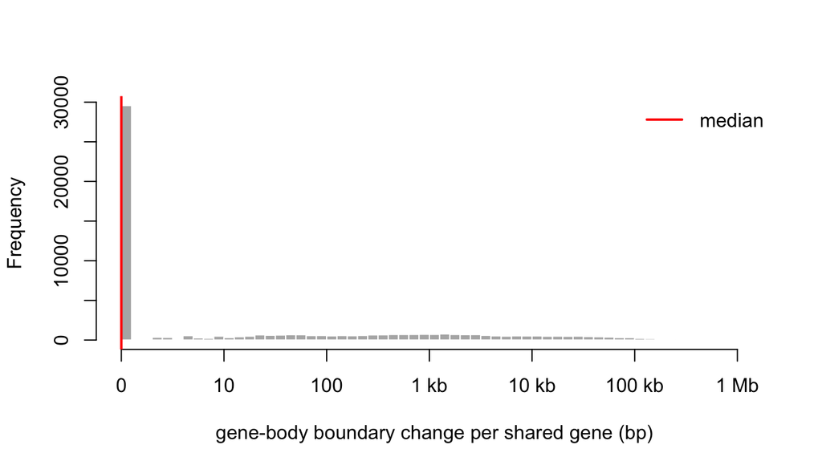

```r
hist(log10(cc2$boundary_bp + 1), breaks = 60, col = "grey70", border = "white",
     main = "", xlab = "gene-body boundary change per shared gene (bp)", xaxt = "n")
axis(1, at = 0:6, labels = c("0", "10", "100", "1 kb", "10 kb", "100 kb", "1 Mb"))
abline(v = log10(median(cc2$boundary_bp) + 1), col = "red", lwd = 2)
legend("topright", bty = "n", lwd = 2, col = "red", legend = "median")
```

# 5. Biotype composition

```r
b_old <- old %>% filter(!retired) %>% count(gene_biotype, name = "n_BRC")
b_new <- gv %>% count(gene_biotype, name = paste0("n_", params$gencode_release))
full_join(b_old, b_new, by = "gene_biotype") %>%
  arrange(desc(dplyr::coalesce(!!sym(paste0("n_", params$gencode_release)), 0L))) %>%
  head(10) %>% kable(caption = "Biotype composition: BRC current annotation vs GENCODE")
```

Biotype composition: BRC current annotation vs GENCODE

| gene_biotype | n_BRC | n_v50 |
| --- | --- | --- |
| lncRNA | 13031 | 34866 |
| protein_coding | 19566 | 20107 |
| processed_pseudogene | 9388 | 9484 |
| misc_RNA | 2200 | 2207 |
| unprocessed_pseudogene | 1808 | 1951 |
| snRNA | 1876 | 1901 |
| miRNA | 1440 | 1878 |
| transcribed_unprocessed_pseudogene | 1432 | 1584 |
| transcribed_processed_pseudogene | 1122 | 1148 |
| TEC | 970 | 1019 |

# 6. Overlap / nesting burden — does GENCODE also need cleaning?

This is the question that decides whether switching would help. Whole-gene-body counting, especially on an unstranded library, is only as clean as the annotation lets it be, so we compute the same overlap and nesting burden for both. If GENCODE were tidier the numbers would be lower; if it is busier — more lncRNAs and antisense loci on top of existing genes — they go up and it needs at least as much filtering as we already do.

```r
of  <- flag_against(old, rep(TRUE, nrow(old))); ofk <- flag_against(old, old$keep)
kable(tibble::tibble(
  Annotation = c("BRC current", paste0("GENCODE ", params$gencode_release)),
  `overlap (all)` = sprintf(c("%.1f%%","%.1f%%"), 100*c(mean(of$ov),  mean(gv$overlaps_full))),
  `nested (all)`  = sprintf(c("%.1f%%","%.1f%%"), 100*c(mean(of$ne),  mean(gv$nested_in_full))),
  `overlap (KEEP)`= sprintf(c("%.1f%%","%.1f%%"), 100*c(mean(ofk$ov[old$keep]), mean(gv$overlaps_keep[gv$keep]))),
  `nested (KEEP)` = sprintf(c("%.1f%%","%.1f%%"), 100*c(mean(ofk$ne[old$keep]), mean(gv$nested_in_keep[gv$keep])))),
  caption = "Overlap / nesting burden (strand-agnostic). Higher = more ambiguous read assignment.")
```

Overlap / nesting burden (strand-agnostic). Higher = more ambiguous read assignment.

| Annotation | overlap (all) | nested (all) | overlap (KEEP) | nested (KEEP) |
| --- | --- | --- | --- | --- |
| BRC current | 59.2% | 32.3% | 53.7% | 18.9% |
| GENCODE v50 | 76.7% | 42.2% | 74.3% | 30.7% |

# 7. Confident set and tiers

Finally, the count that matters: how many genes we would actually keep, and how many reach high confidence, under each annotation. A bigger raw gene set is not worth much if it does not turn into more genes we trust. The columns are the same filters used in `GeneSet_Filtering.Rmd` — `keep`, evidence-only `high`, `high` with the gene-nesting filter applied (`high (no nested)`), and `high+medium` — computed the same way on both annotations, so they are directly comparable.

```r
kable(tibble::tibble(
  Annotation = c("BRC current", paste0("GENCODE ", params$gencode_release)),
  KEEP = c(sum(old$keep), sum(gv$keep)),
  high = c(sum(old$keep_high), sum(gv$keep_high)),
  `high (no nested)` = c(sum(old$keep_high_no_nested), sum(gv$keep_high_no_nested)),
  `high+medium` = c(sum(old$keep_high_medium), sum(gv$keep_high_medium))),
  caption = "Confident gene counts by annotation (same filters as the confidence report)")
```

Confident gene counts by annotation (same filters as the confidence report)

| Annotation | KEEP | high | high (no nested) | high+medium |
| --- | --- | --- | --- | --- |
| BRC current | 32597 | 24196 | 21283 | 32210 |
| GENCODE v50 | 54973 | 24994 | 20924 | 29410 |

# 8. Conclusion

Most of the BRC annotation has held up: 91.9% of its genes are still in GENCODE v50, only 4867 (8.1%) have been retired, and GENCODE has added 23493 genes we never had, almost all of them lncRNAs. A move is not free, though: only 53.5% of the shared genes have identical gene bodies, so switching would force a re-count rather than a relabel. And it would not buy us a cleaner annotation — the KEEP-set overlap burden is 53.7% for the BRC set against 74.3% for GENCODE v50, i.e. GENCODE is if anything busier and needs the same filtering, not less. The number of genes we would actually trust is about the same either way (24196 high-confidence versus 24994); the extra GENCODE genes are overwhelmingly low-confidence lncRNA. So GENCODE is the better base if we want that expanded lncRNA catalogue, but for a protein-coding-focused analysis the cleaned BRC annotation is essentially equivalent, and the cleaning is what matters in both cases.